# PM 566 HW 3

Chris Hanson

11/5/2021

```r
library(httr)
library(xml2)
library(stringr)
library(tidyverse)
library(data.table)
library(tidytext)
library(ggplot2)
```

# 1. APIs

### Using the NCBI API, look for papers that show up under the term “sars-cov-2 trial vaccine.” Look for the data in the PubMed database, and then retrieve the details of the paper (as shown in lab 7), including the PubMed IDs.

```r
# Accessing the PubMed database through the NCBI API and searching for "sars-cov-2 trial  vaccine".
query_ids <- GET(
  url = "https://eutils.ncbi.nlm.nih.gov/",
  path = "entrez/eutils/esearch.fcgi",
  query = list(db = "pubmed",
               term = "sars-cov-2 trial vaccine",
               retmax = 10000)
)

ids <- content(query_ids)

ids <- as.character(ids)

ids <- str_extract_all(ids, "<Id>[[:digit:]]+</Id>")[[1]]

ids <- str_remove_all(ids, "<Id>|</Id>")
```

I found 1041 papers.

Using the list of Pubmed IDs retrieved, download each paper’s details using the query parameter rettype = abstract. Keep just the first 250.

```r
publications <- GET(
  url   = "https://eutils.ncbi.nlm.nih.gov/",
  path = "entrez/eutils/efetch.fcgi",
  query = list(
    db = "pubmed",
    id = I(paste(ids[1:250], collapse=",")),
    retmax = 10000,
    rettype = "abstract"
    )
)

# Extracting the content of the results of GET into an XML object:
publications <- httr::content(publications)

# Turning this XML object into characters:
publications_txt <- as.character(publications)
```

Create a dataset containing the following:

PubMed ID number

Title of the paper

Name of the journal where it was published

Publication date

Abstract of the paper

```r
pub_char_list <- xml_children(publications)
pub_char_list <- sapply(pub_char_list, as.character)

abstracts <- str_extract(pub_char_list, "<Abstract>[[:print:][:space:]]+</Abstract>")
abstracts <- str_remove_all(abstracts, "</?[[:alnum:]- =\"]+.")
abstracts <- str_replace_all(abstracts, "[[:space:]]+", " ")

titles <- str_extract(pub_char_list, "<ArticleTitle>[[:print:][:space:]]+</ArticleTitle>")
titles <- str_remove_all(titles, "</?[[:alnum:]- =\"]+>")

journals <- str_extract(pub_char_list, "<Title>[[:print:][:space:]]+</Title>")
journals <- str_remove_all(journals, "</?[[:alnum:]- =\"]+>")

#dates <- str_extract(pub_char_list, "<PubDate>[[:print:][:space:]]+</PubDate>")
dates <- str_extract(pub_char_list, "<DateRevised>[[:print:][:space:]]+</DateRevised>")
dates <- str_remove_all(dates, "</?[[:alnum:]- =\"]+>")
dates <- str_replace_all(dates, "[[:space:]]+", " ")
dates <- trimws(dates, which = c("both"))
dates <- format(as.Date(dates, "%Y %m %d"), "%m/%d/%Y")



database <- data.frame(
  PubMedId = ids[1:250],
  Title    = titles,
  Journal  = journals,
  Date     = dates,
  Abstract = abstracts
)
knitr::kable(database[1:5,], caption = "Covid19 Vaccine Trial")
```

Covid19 Vaccine Trial

| PubMedId | Title | Journal | Date | Abstract |
| --- | --- | --- | --- | --- |
| 34726743 | Analysis of the Effectiveness of the Ad26.COV2.S Adenoviral Vector Vaccine for Preventing COVID-19. | JAMA network open | 11/03/2021 | Continuous assessment of the effectiveness and safety of the US Food and Drug Administration-authorized SARS-CoV-2 vaccines is critical to amplify transparency, build public trust, and ultimately impr… |
| 34713912 | Vaccine development and technology for SARS-CoV-2: current insights. | Journal of medical virology | 10/29/2021 | SARS-CoV-2 is associated to a severe respiratory disease in China, that rapidly spread across continents. Since the beginning of the pandemic, available data suggested the asymptomatic transmission an… |
| 34711598 | BCG vaccination to reduce the impact of COVID-19 in healthcare workers: Protocol for a randomised controlled trial (BRACE trial). | BMJ open | 11/03/2021 | BCG vaccination modulates immune responses to unrelated pathogens. This off-target effect could reduce the impact of emerging pathogens. As a readily available, inexpensive intervention that has a wel… |
| 34704204 | COVID-19 Testing and Vaccine Acceptability Among Homeless-Experienced Adults: Qualitative Data from Two Samples. | Journal of general internal medicine | 10/29/2021 | Homeless-experienced populations are at increased risk of exposure to SARS-CoV-2 due to their living environments and face an increased risk of severe COVID-19 disease due to underlying health conditi… |
| 34703690 | A Rare Variant of Guillain-Barre Syndrome Following Ad26.COV2.S Vaccination. | Cureus | 10/28/2021 | Efforts to combat the global pandemic caused by severe acute respiratory syndrome coronavirus 2 (SARS-CoV-2) range from adequate diagnostic testing and contract tracing to vaccination for the preventi… |

# 2. Text Mining

### A dataset from the course data repository contains 3241 abstracts from articles across 5 search terms. Analyse these abstracts to find interesting insights.

Tokenize the abstracts and count the number of each token.

```r
# Importing the dataset
mining_abstracts <- read_csv("pubmed.csv")
mining_abstracts <- as_tibble(mining_abstracts)

# Discovering the 5 topics of the abstracts provided
terms <- mining_abstracts %>%
  count(term) %>%
  arrange(desc(n))

# Tokenize the abstracts and count the number of each token--------------------

# All abstracts, stop words not removed
mining_abstracts %>%
  unnest_tokens(output = word, input = abstract) %>%
  count(word, sort = TRUE) %>%
  top_n(10) %>%
  knitr::kable()
```

| word | n |
| --- | --- |
| the | 28126 |
| of | 24760 |
| and | 19993 |
| in | 14653 |
| to | 10920 |
| a | 8245 |
| with | 8038 |
| covid | 7275 |
| 19 | 7080 |
| is | 5649 |

```r
# All abstracts, stop words and numbers removed
tokens <- mining_abstracts %>%
  unnest_tokens(output = word, input = abstract) %>%
  count(word, sort = TRUE) %>%
  anti_join(stop_words, by = "word") %>%
  filter(!grepl(pattern = "^[0-9]+$", x = word))

tokens %>%
  top_n(10) %>%
  knitr::kable()
```

| word | n |
| --- | --- |
| covid | 7275 |
| patients | 4674 |
| cancer | 3999 |
| prostate | 3832 |
| disease | 2574 |
| pre | 2165 |
| eclampsia | 2005 |
| preeclampsia | 1863 |
| treatment | 1841 |
| clinical | 1682 |

```r
# Tokenizing per search term----------------------------------------------------

tokens2 <- mining_abstracts %>%
  unnest_tokens(output = word, input = abstract) %>%
  count(word, term, sort = TRUE) %>%
  anti_join(stop_words, by = "word") %>%
  filter(!grepl(pattern = "^[0-9]+$", x = word))

# Covid abstracts
tokens2 %>%
  filter(term == "covid") %>%
  top_n(5) %>%
  knitr::kable()
```

| word | term | n |
| --- | --- | --- |
| covid | covid | 7275 |
| patients | covid | 2293 |
| disease | covid | 943 |
| pandemic | covid | 800 |
| coronavirus | covid | 647 |
| health | covid | 647 |

```r
# Cystic fibrosis abstracts
tokens2 %>%
  filter(term == "cystic fibrosis") %>%
  top_n(5) %>%
  knitr::kable()
```

| word | term | n |
| --- | --- | --- |
| fibrosis | cystic fibrosis | 867 |
| cystic | cystic fibrosis | 862 |
| cf | cystic fibrosis | 625 |
| patients | cystic fibrosis | 586 |
| disease | cystic fibrosis | 400 |

```r
# Meningitis abstracts
tokens2 %>%
  filter(term == "meningitis") %>%
  top_n(5) %>%
  knitr::kable()
```

| word | term | n |
| --- | --- | --- |
| patients | meningitis | 446 |
| meningitis | meningitis | 429 |
| meningeal | meningitis | 219 |
| csf | meningitis | 206 |
| clinical | meningitis | 187 |

```r
# Preeclampsia abstracts
tokens2 %>%
  filter(term == "preeclampsia") %>%
  top_n(5) %>%
  knitr::kable()
```

| word | term | n |
| --- | --- | --- |
| pre | preeclampsia | 2038 |
| eclampsia | preeclampsia | 2005 |
| preeclampsia | preeclampsia | 1863 |
| women | preeclampsia | 1196 |
| pregnancy | preeclampsia | 969 |

```r
# Prostate cancer abstracts
tokens2 %>%
  filter(term == "prostate cancer") %>%
  top_n(5) %>%
  knitr::kable()
```

| word | term | n |
| --- | --- | --- |
| cancer | prostate cancer | 3840 |
| prostate | prostate cancer | 3832 |
| patients | prostate cancer | 934 |
| treatment | prostate cancer | 926 |
| disease | prostate cancer | 652 |

Tokenize the abstracts into bigrams. Find the 10 most common bigrams and visualize them with ggplot2.

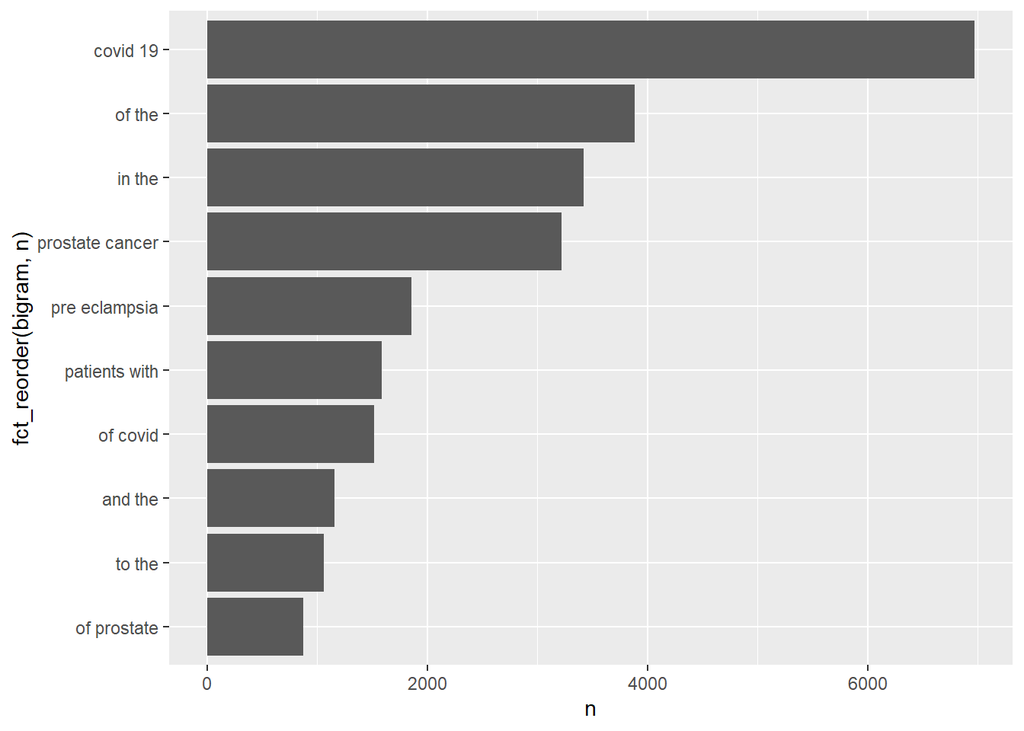

```r
mining_abstracts %>%
  unnest_ngrams(output = bigram, input = abstract, n = 2) %>%
  count(bigram, sort = TRUE) %>%
  top_n(10) %>%
  ggplot(aes(x = n, y = fct_reorder(bigram, n))) +
  geom_col()
```

Calculate the TF-IDF value for each word-search term combination (the search term is the “document”). What are the 5 tokens from each search term with the highest TF-IDF value? How are the results different from the answers from question 1?

(TF-IDF is term frequency x inverse document frequency, it’s a measure of how unique a term is to a single document)

```r
tfidf <- mining_abstracts %>%
  unnest_tokens(output = word, input = abstract) %>%
  count(word, term) %>%
  bind_tf_idf(word, term, n) %>%
  arrange(desc(tf_idf))

tfidf %>%
  filter(term == "covid") %>%
  top_n(5) %>%
  knitr::kable()
```

| word | term | n | tf | idf | tf_idf |
| --- | --- | --- | --- | --- | --- |
| covid | covid | 7275 | 0.0371050 | 1.609438 | 0.0597183 |
| pandemic | covid | 800 | 0.0040803 | 1.609438 | 0.0065670 |
| coronavirus | covid | 647 | 0.0032999 | 1.609438 | 0.0053110 |
| sars | covid | 372 | 0.0018973 | 1.609438 | 0.0030536 |
| cov | covid | 334 | 0.0017035 | 1.609438 | 0.0027417 |

```r
tfidf %>%
  filter(term == "cystic fibrosis") %>%
  top_n(5) %>%
  knitr::kable()
```

| word | term | n | tf | idf | tf_idf |
| --- | --- | --- | --- | --- | --- |
| cf | cystic fibrosis | 625 | 0.0127188 | 0.9162907 | 0.0116541 |
| fibrosis | cystic fibrosis | 867 | 0.0176435 | 0.5108256 | 0.0090127 |
| cystic | cystic fibrosis | 862 | 0.0175417 | 0.5108256 | 0.0089608 |
| cftr | cystic fibrosis | 86 | 0.0017501 | 1.6094379 | 0.0028167 |
| sweat | cystic fibrosis | 83 | 0.0016891 | 1.6094379 | 0.0027184 |

```r
tfidf %>%
  filter(term == "meningitis") %>%
  top_n(5) %>%
  knitr::kable()
```

| word | term | n | tf | idf | tf_idf |
| --- | --- | --- | --- | --- | --- |
| meningitis | meningitis | 429 | 0.0091942 | 1.6094379 | 0.0147974 |
| meningeal | meningitis | 219 | 0.0046935 | 1.6094379 | 0.0075539 |
| pachymeningitis | meningitis | 149 | 0.0031933 | 1.6094379 | 0.0051394 |
| csf | meningitis | 206 | 0.0044149 | 0.9162907 | 0.0040453 |
| meninges | meningitis | 106 | 0.0022718 | 1.6094379 | 0.0036562 |

```r
tfidf %>%
  filter(term == "preeclampsia") %>%
  top_n(5) %>%
  knitr::kable()
```

| word | term | n | tf | idf | tf_idf |
| --- | --- | --- | --- | --- | --- |
| eclampsia | preeclampsia | 2005 | 0.0142784 | 1.6094379 | 0.0229802 |
| preeclampsia | preeclampsia | 1863 | 0.0132672 | 1.6094379 | 0.0213527 |
| pregnancy | preeclampsia | 969 | 0.0069006 | 0.5108256 | 0.0035250 |
| maternal | preeclampsia | 797 | 0.0056757 | 0.5108256 | 0.0028993 |
| gestational | preeclampsia | 191 | 0.0013602 | 1.6094379 | 0.0021891 |

```r
tfidf %>%
  filter(term == "prostate cancer") %>%
  top_n(5) %>%
  knitr::kable()
```

| word | term | n | tf | idf | tf_idf |
| --- | --- | --- | --- | --- | --- |
| prostate | prostate cancer | 3832 | 0.0311890 | 1.609438 | 0.0501967 |
| androgen | prostate cancer | 305 | 0.0024824 | 1.609438 | 0.0039953 |
| psa | prostate cancer | 282 | 0.0022952 | 1.609438 | 0.0036940 |
| prostatectomy | prostate cancer | 215 | 0.0017499 | 1.609438 | 0.0028164 |
| castration | prostate cancer | 148 | 0.0012046 | 1.609438 | 0.0019387 |

For the COVID abstracts, the top used words and the top TF-IDF shared 3 of 5 words.

For the cystic fibrosis abstracts, the top used words and the top TF-IDF shared 3 of 5 words.

For the meningitis abstracts, the top used words and the top TF-IDF shared 3 of 5 words.

For the preeclampsia abstracts, the top used words and the top TF-IDF shared 3 of 5 words.

For the prostate cancer abstracts, the top used words and the top TF-IDF shared 1 of 5 words.